# GABF

Mike Wehinger

20/10/2020

## Explore Data

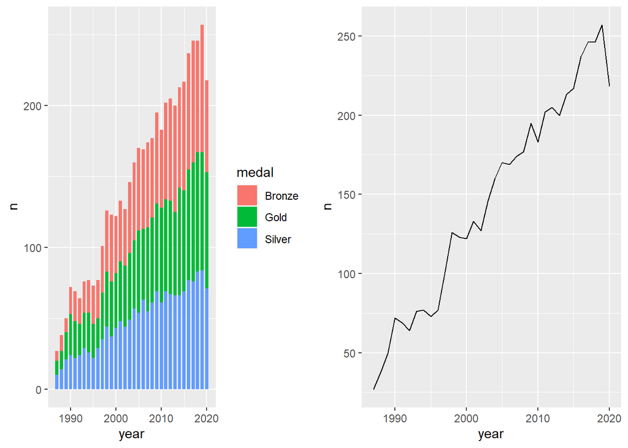

There were 515 different categories used in the dataset (from 1987 to 2020), but only 90 used in 2020 meaning,

- Some categories were dropped or added
- Some categories could be renamed

Top 20 most used categories

| category | n |
| --- | --- |
| Classic Irish-Style Dry Stout | 62 |
| American-Style Pale Ale | 61 |
| Bock | 61 |
| Robust Porter | 61 |
| Imperial Stout | 60 |
| German-Style Pilsener | 59 |
| German-Style Wheat Ale | 56 |
| American-Style Amber Lager | 55 |
| Brown Porter | 55 |
| Irish-Style Red Ale | 53 |
| American-Style Brown Ale | 51 |
| Golden or Blonde Ale | 49 |
| Vienna-Style Lager | 49 |
| American-Style India Pale Ale | 48 |
| Oatmeal Stout | 48 |
| Barley Wine-Style Ale | 47 |
| Rye Beer | 47 |
| Specialty Beer | 47 |
| Experimental Beer | 45 |
| Scottish-Style Ale | 45 |

Top 20 2020

| category | n |
| --- | --- |
| American-Style Amber/Red Ale | 3 |
| American-Style Brown Ale | 3 |
| American-Style Fruit Beer | 3 |
| American-Style Pale Ale | 3 |
| American-Style Strong Pale Ale | 3 |
| American Amber Lager | 3 |
| American Lager | 3 |
| American Pilsener | 3 |
| Belgian-Style Lambic or Sour Ale | 3 |
| Belgian-Style Specialty Ale | 3 |
| Belgian-Style Witbier | 3 |
| Bock | 3 |
| Bohemian-Style Pilsener | 3 |
| Classic Saison | 3 |
| Coffee Beer | 3 |
| Coffee Stout or Porter | 3 |
| Contemporary Gose | 3 |
| English Ale | 3 |
| English Mild or Bitter | 3 |
| Experimental Beer | 3 |

| SimpleCat | n |
| --- | --- |
| Lager | 554 |
| Pale Ale | 420 |
| Stout | 388 |
| German Style | 387 |
| Belgian Beer | 372 |
| Pilsener | 213 |
| Wheat Beer | 191 |
| Porter | 167 |
| Fruit Beer | 162 |
| Red Ale | 157 |
| Brown Ale | 150 |
| Bitter | 134 |
| Sour | 107 |
| Aged | 100 |
| Bock | 88 |
| Golden or Blonde Ale | 81 |
| Barley Wine | 77 |
| Smoke Flavored | 73 |
| Scottish-Style Ale | 63 |
| Specialty Beer | 52 |
| Rye Beer | 47 |
| Coffee Flavored | 46 |
| Experimental Beer | 45 |
| Summer Ale | 44 |
| Session | 27 |

Start to explore how the styles have changed from 1999 to 2019 and what might be a good visualization

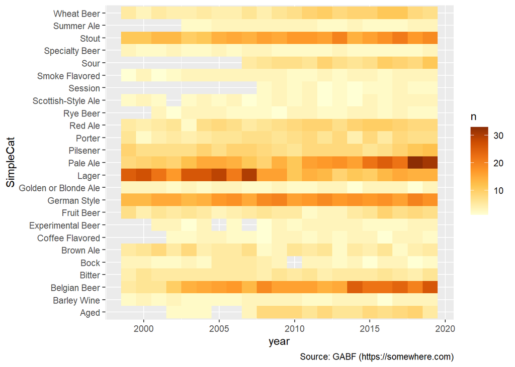

```
## [1] "A Streamgraph..."
```

[interactive chart not shown]

```
## [1] "A Streamgraph with original categories in 'other'..."
```

[interactive chart not shown]

```
## [1] "Another Streamgraph..."
```

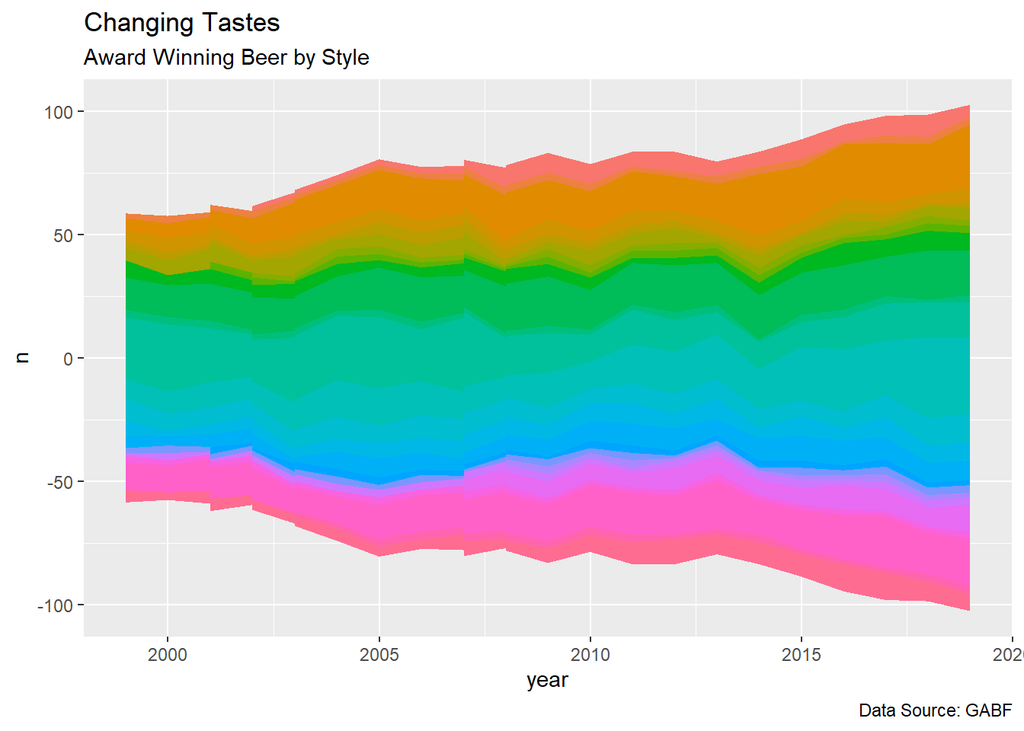

```
## [1] "A bar chart"
```

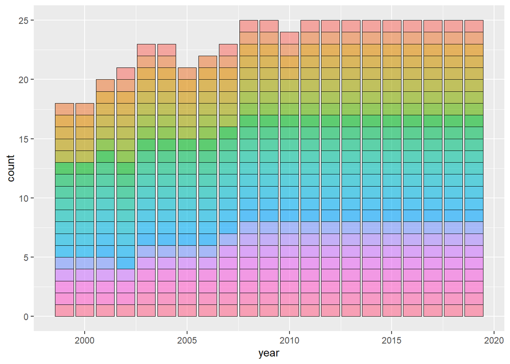

The streamgraph looks cool as is but need to narrow the number of beer categories down and find a way to display a non-interactive legend (or labels)

Now separate charts to show more detailed styles that are, 1 - gaining in popularity and 2 - declining in popularity

Beer Styles w/ increasing award counts

| year | SimpleCat | n | topCat | move |
| --- | --- | --- | --- | --- |
| 2019 | Pale Ale | 31 | Y | 23 |
| 2019 | Belgian Beer | 26 | Y | 21 |
| 2019 | Sour | 11 | Y | 11 |
| 2019 | Stout | 19 | Y | 8 |

Dncreasing award counts

| year | SimpleCat | n | topCat | move |
| --- | --- | --- | --- | --- |
| 2019 | Bock | 2 | N | -1 |
| 2019 | Coffee Flavored | 2 | N | -2 |
| 2019 | Smoke Flavored | 3 | N | -5 |
| 2019 | Lager | 14 | Y | -11 |

Putting the charts together and adding titles and clean-up…

**Top Beer Styles Awarded from 1999 to 2019**

[interactive chart not shown]

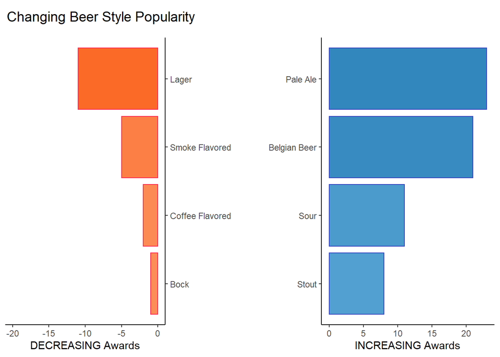